# Psych201a, Problem Set 2: Tidying Data

# Groups, Summaries, and Results

## Performance Hypothesis

For the performance data, we need to do a little bit of manipulation of the columns in order to get to the performance measures the experimenters actually used. Because they want to compare changes in performance across games that have very different scoring systems, the easiest solution is to compare z-scores. The way they did this was to z-score performance before music, z-score performance after music, and then create a difference measure which is a difference of z-scores. (To my mind, this is actually not quite the correct way to analyze this data, but like the replication we will follow the original authors.)

We’ll add a new z-scored value column. However, we have to be careful! We want to z-score within *groups* of the rows, that are all the same type of measurement. For example, we want to z-score the “DinnerDashWithMusic” scores with respect to eachother, but **not** with respect to the scores from the other game, for example. We can use the `group_by` function to set groups, and then all the changes we apply will only occur within those groups until we `ungroup` the dataset.

To make this more concrete, let’s see how the `group_by` function can let us compute means within different groups, for example mean scores on the two different games.

```r
performance_hyp_long_d |>
  group_by(ConfrontationalGame, WithMusic) |>
  summarize(AvgScore = mean(Score, na.rm=T)) # the na.rm tells R to ignore NA values
```

```
# A tibble: 4 × 3
# Groups:   ConfrontationalGame [2]
  ConfrontationalGame WithMusic AvgScore
  <lgl>               <lgl>        <dbl>
1 FALSE               FALSE       4687.
2 FALSE               TRUE        5930.
3 TRUE                FALSE         20.6
4 TRUE                TRUE          24.1
```

This makes it clear why we can’t just z-score the games together! The scores are very different between games. So let’s z-score within groups (using the `scale` function):

```r
performance_hyp_long_d = performance_hyp_long_d |>
  group_by(ConfrontationalGame, WithMusic) |> # we're going to compute four sets of z-scores, one for the confrontational game without music, one for the confrontational game with, one for the nonconfrontational game without music, and one for the nonconfrontational game with
  mutate(z_scored_performance = scale(Score)) |>
  ungroup()
```

## Rating Hypothesis

The rating hypothesis analysis also requires some grouped manipulation. The experimenters collected repeated measures on ratings in each emotion category and each music/recall category from each game. For this analysis, they averaged all the ratings over the following two variables: the given emotion and the game type, to produce a nice summary. Your job is to implement this, calling the new variable MeanRating, and save the summarized data in a new data frame called `rating_summary_d`. (Hint: use a `group_by` and a `summarize`.)

```r
rating_summary_d = rating_hyp_long_d |>
  group_by(ConfrontationalGame, Emotion) |>
  summarize(MeanRating = mean(Rating, na.rm=T)) |>
  ungroup()
  ## your code here
```

Let’s take a look at the result:

```r
rating_summary_d
```

```
# A tibble: 6 × 3
  ConfrontationalGame Emotion  MeanRating
  <lgl>               <chr>         <dbl>
1 FALSE               Angry          2.72
2 FALSE               Exciting       3.97
3 FALSE               Neutral        3.68
4 TRUE                Angry          4.68
5 TRUE                Exciting       3.05
6 TRUE                Neutral        2.16
```

And a simple bar plot (don’t worry too much about what exactly this code is doing):

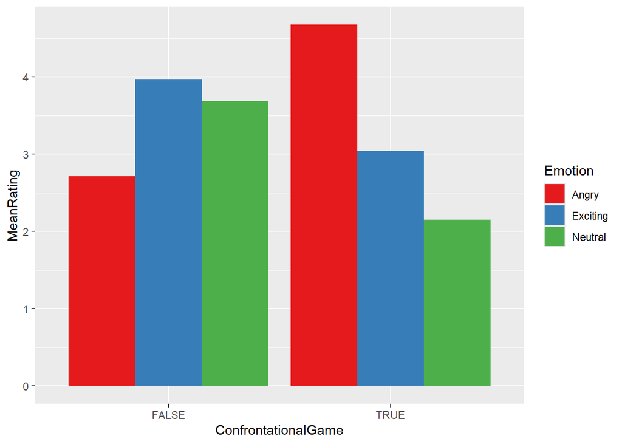

```r
ggplot(rating_summary_d, aes(x=ConfrontationalGame, y=MeanRating, fill=Emotion)) +
  geom_bar(position="dodge", stat="identity") +
  scale_fill_brewer(palette="Set1")
```

## Performance Hypothesis (Continued)

There are still a few more steps to go for the performance hypothesis. We need to take a difference score to see how people improved from before hearing the music to after, and then see if the improvement is larger if they heard music congruent with the type of game.

To compute the difference score, we have to make our data a bit wider. We now want to subtract the pre-music scores from the post-music scores, which is easiest to do if they are in two different columns. To do this we’ll use the `pivot_wider` function (which is more or less the opposite of `pivot_longer`)

```r
performance_diff_d = performance_hyp_long_d |>
  # re-label variable so code is easier to read
  mutate(WithMusic = factor(WithMusic, levels=c(F, T), labels=c("PreMusic", "PostMusic"))) |>
  # now we remove columns we don't need (why might this be?)
  select(-c("Score", "Measurement")) |>
  pivot_wider(names_from=WithMusic,
              values_from=z_scored_performance) |>
  mutate(ImprovementScore=PostMusic-PreMusic)
```

Let’s take a look at the end result:

```r
performance_diff_d
```

```
# A tibble: 94 × 7
   Subject  Cond ConfrontationalGame MusicCondition PostMusic[,1] PreMusic[,1]
     <dbl> <dbl> <lgl>               <fct>                  <dbl>        <dbl>
 1       1     2 FALSE               Exciting             -0.150         0.265
 2       1     2 TRUE                Exciting             -1.30          0.317
 3       3     1 FALSE               Anger                -0.844        -2.91
 4       3     1 TRUE                Anger                -0.283        -1.29
 5       6     3 FALSE               Neutral               0.679         0.975
 6       6     3 TRUE                Neutral              -0.0272        0.546
 7       9     2 FALSE               Exciting              0.770         1.50
 8       9     2 TRUE                Exciting             -2.07         -0.599
 9      10     1 FALSE               Anger                -0.678        -1.44
10      10     1 TRUE                Anger                -0.0272       -1.06
# ℹ 84 more rows
# ℹ 1 more variable: ImprovementScore <dbl[,1]>
```

If you don’t understand every step of that code (or any other `dplyr` code), it can be helpful to look at the result of running just the first line, then just the first two lines, and so on.

Now we’re finally to reproduce Fig. 2 from Tamir et al., we just need to get the mean differences within each game and each kind of music, and save them to a variable called `MeanImprovementScore`:

```r
performance_summary_d = performance_diff_d |>
  group_by(ConfrontationalGame, MusicCondition) |>
  summarize(MeanImprovementScore = mean(ImprovementScore, na.rm=T)) |>
  ungroup()
  # your code here
```

```r
performance_summary_d
```

```
# A tibble: 6 × 3
  ConfrontationalGame MusicCondition MeanImprovementScore
  <lgl>               <fct>                         <dbl>
1 FALSE               Anger                       -0.0552
2 FALSE               Exciting                    -0.226
3 FALSE               Neutral                      0.310
4 TRUE                Anger                        0.348
5 TRUE                Exciting                    -0.146
6 TRUE                Neutral                     -0.0879
```

and plot it!

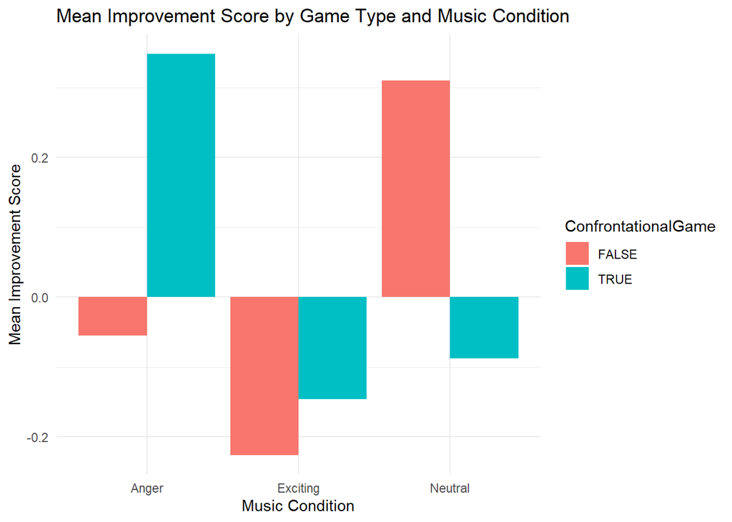

```r
ggplot(performance_summary_d, aes(x = MusicCondition, y = MeanImprovementScore, fill = ConfrontationalGame)) +
  geom_bar(stat = "identity", position = position_dodge()) +
  labs(title = "Mean Improvement Score by Game Type and Music Condition",
       x = "Music Condition",
       y = "Mean Improvement Score") +
  theme_minimal()
```

```r
performance_SEM_d = performance_diff_d |>
  group_by(ConfrontationalGame, MusicCondition) |>
  summarise(
    MeanImprovementScore = mean(ImprovementScore),
    StandardDeviation = sd(ImprovementScore),
    n = n(),
    StandardErrorMean = StandardDeviation / sqrt(n)
  )
performance_SEM_d
```

```
# A tibble: 6 × 6
# Groups:   ConfrontationalGame [2]
  ConfrontationalGame MusicCondition MeanImprovementScore StandardDeviation
  <lgl>               <fct>                         <dbl>             <dbl>
1 FALSE               Anger                       -0.0552             1.27
2 FALSE               Exciting                    -0.226              0.558
3 FALSE               Neutral                      0.310              0.997
4 TRUE                Anger                        0.348              1.06
5 TRUE                Exciting                    -0.146              1.09
6 TRUE                Neutral                     -0.0879             0.825
# ℹ 2 more variables: n <int>, StandardErrorMean <dbl>
```

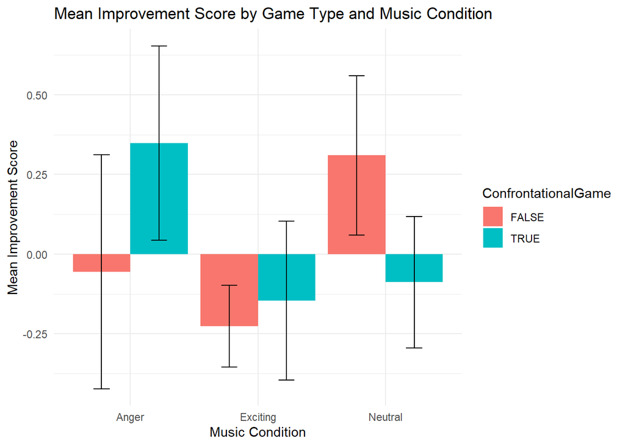

```r
ggplot(performance_SEM_d, aes(x = MusicCondition, y = MeanImprovementScore, fill = ConfrontationalGame)) +
  geom_bar(stat = "identity", position = position_dodge()) +
  geom_errorbar(aes(ymin = MeanImprovementScore - StandardErrorMean, ymax = MeanImprovementScore + StandardErrorMean),
                position = position_dodge(0.9), width = 0.25) +
  labs(title = "Mean Improvement Score by Game Type and Music Condition",
       x = "Music Condition",
       y = "Mean Improvement Score") +
  theme_minimal()
```

(Bonus: also calculate the SEM in the summary data, and then add errorbars to the plot with `geom_errorbar`!)

Not quite as exact a replication of the effect as Fig. 1. This concurs with the [replication report](https://osf.io/7i2tf/), which says that the hypothesis 1 effect replicated, but hypothesis 2 did not.